# Pantaleo exploratory analysis - TFH041

Kushal K Dey, Valentin Voillet

7/18/2017

# 1 Data Loading & Description

Briefly, paired PBMCs (Peripheral blood mononuclear cells) and LN (Lymph Node) from patients were stained and sorted for TFH (T Follicular Helper) and Live cells. There are three HIV+ CP off treatment and three HIV- patients.

Per patient, per sample, two Seq-Well arrays were processed. *NB: each patient has the following processed array conditions: LN TFH, LN Live, PBMC TFH, & PBMC Live.*

Here - we have four arrays from one HIV- CP patient.

**Obj: Re-perform the analysis // Look at the data.**

Live cells

TFH cells (LN + PBMC)

```r
TFH_LN_UMI <- read.table('TFH041/TFH Sorted/LN/reads.TFH041_TFH_LN_S1_R1_001.fastq_bq10_star_corrected.umi.dge.txt', header = TRUE, row.names = 1)
TFH_LN_reads <- read.table('TFH041/TFH Sorted/LN/reads.TFH041_TFH_LN_S1_R1_001.fastq_bq10_star_corrected.reads.dge.txt', header = TRUE, row.names = 1)
TFH_LN_UMI_summary <- read.table('TFH041/TFH Sorted/LN/reads.TFH041_TFH_LN_S1_R1_001.fastq_bq10_star_corrected.umi.dge.summary.txt', header = TRUE, row.names = 1)
TFH_LN_reads_summary <- read.table('TFH041/TFH Sorted/LN/reads.TFH041_TFH_LN_S1_R1_001.fastq_bq10_star_corrected.reads.dge.summary.txt', header = TRUE, row.names = 1)
#- First filtering - remove cells with less than 10 genes
TFH_LN_UMI <- TFH_LN_UMI[, rownames(TFH_LN_reads_summary)[which(TFH_LN_reads_summary$NUM_GENES > 10)]]
TFH_LN_reads <- TFH_LN_reads[, rownames(TFH_LN_reads_summary)[which(TFH_LN_reads_summary$NUM_GENES > 10)]]
TFH_LN_UMI_summary <- TFH_LN_UMI_summary[colnames(TFH_LN_UMI), ]
TFH_LN_reads_summary <- TFH_LN_reads_summary[colnames(TFH_LN_reads), ]

##- PBMC
TFH_PBMC_UMI <- read.table('TFH041/TFH Sorted/PBMC/reads.TFH041_TFH_PBMC_S2_R1_001.fastq_bq10_star_corrected.umi.dge.txt', header = TRUE, row.names = 1)
TFH_PBMC_reads <- read.table('TFH041/TFH Sorted/PBMC/reads.TFH041_TFH_PBMC_S2_R1_001.fastq_bq10_star_corrected.reads.dge.txt', header = TRUE, row.names = 1)
TFH_PBMC_UMI_summary <- read.table('TFH041/TFH Sorted/PBMC/reads.TFH041_TFH_PBMC_S2_R1_001.fastq_bq10_star_corrected.umi.dge.summary.txt', header = TRUE, row.names = 1)
TFH_PBMC_reads_summary <- read.table('TFH041/TFH Sorted/PBMC/reads.TFH041_TFH_PBMC_S2_R1_001.fastq_bq10_star_corrected.reads.dge.summary.txt', header = TRUE, row.names = 1)
#- First filtering - remove cells with less than 10 genes
TFH_PBMC_UMI <- TFH_PBMC_UMI[, rownames(TFH_PBMC_reads_summary)[which(TFH_PBMC_reads_summary$NUM_GENES > 10)]]
TFH_PBMC_reads <- TFH_PBMC_reads[, rownames(TFH_PBMC_reads_summary)[which(TFH_PBMC_reads_summary$NUM_GENES > 10)]]
TFH_PBMC_UMI_summary <- TFH_PBMC_UMI_summary[colnames(TFH_PBMC_UMI), ]
TFH_PBMC_reads_summary <- TFH_PBMC_reads_summary[colnames(TFH_PBMC_reads), ]
```

# 2 Live Cells

## 2.1 Raw Count

Let’s look at the distribution of UMIs and nb. of detected genes in both LN and PBMC samples for Live Cells.

*NB: We do not have information about read distribution.*

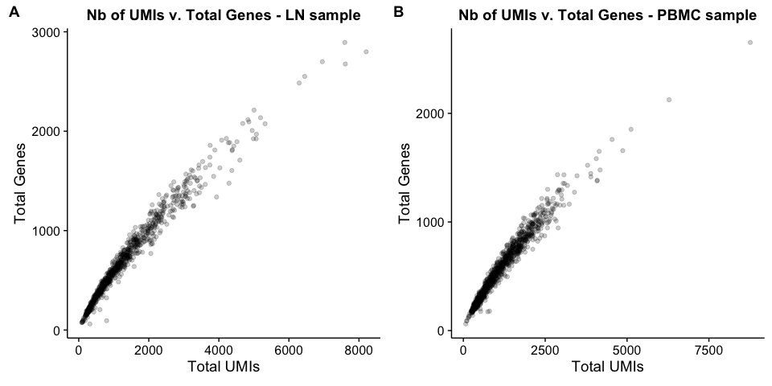

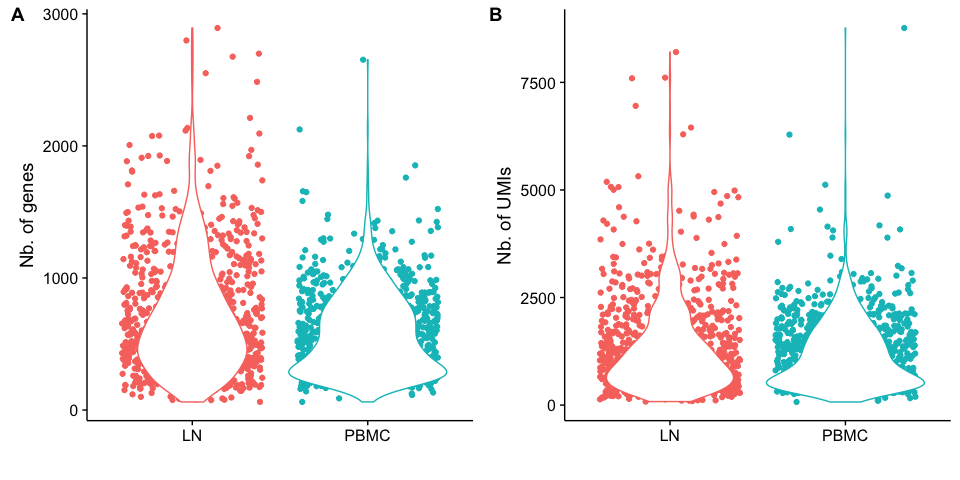

Close nb. of UMIs and detected genes are observed in bith LN and PBMC samples from Live Cells.  
## QC and Filtering

The next step is then to perform quality control and filtering (remove cells with few reads/UMIs or genes, etc.).

The threshold that Sam used was **750 UMIs** and **400 genes** (see *Slides for Pantaleo 053017.ppt* file - HIV+ patient). So, let’s use the same here, and also remove genes with less than one UMI count.

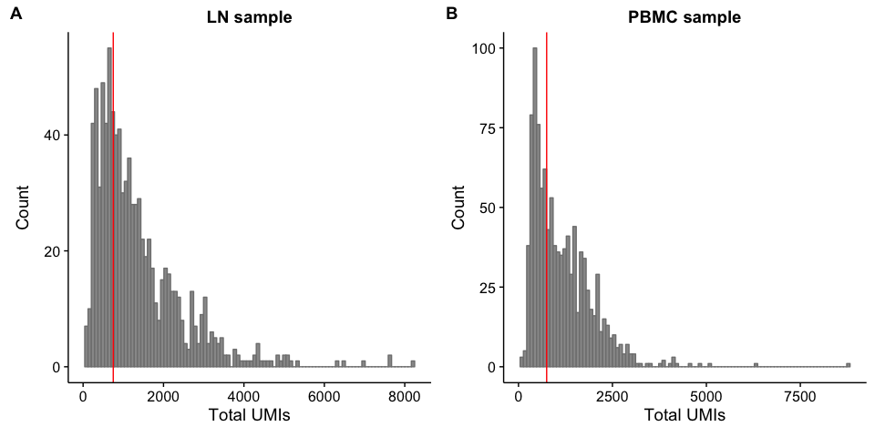

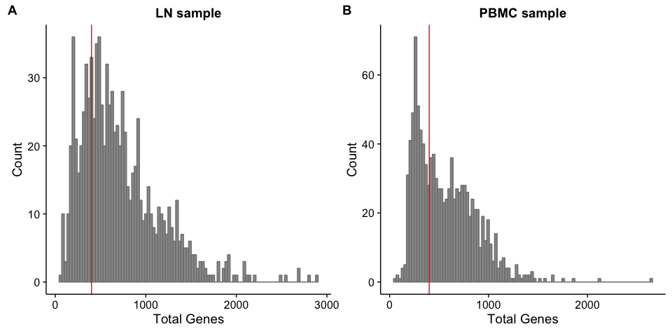

```r
###--- Filtering datasets and merging
#- LN
identical(colnames(LiveCells_LN_UMI), rownames(LiveCells_LN_UMI_summary)) # TRUE
```

```
## [1] TRUE
```

```r
LiveCells_LN_UMI_filtered <- LiveCells_LN_UMI[, which(LiveCells_LN_UMI_summary$NUM_GENES >= 400 & LiveCells_LN_UMI_summary$NUM_TRANSCRIPTS >= 750)]
LiveCells_LN_UMI_filtered <- LiveCells_LN_UMI_filtered[which(apply(LiveCells_LN_UMI_filtered, 1, sum) != 0), ]
#- PBMC
identical(colnames(LiveCells_PBMC_UMI), rownames(LiveCells_PBMC_UMI_summary)) # TRUE
```

```
## [1] TRUE
```

```r
LiveCells_PBMC_UMI_filtered <- LiveCells_PBMC_UMI[, which(LiveCells_PBMC_UMI_summary$NUM_GENES >= 400 & LiveCells_PBMC_UMI_summary$NUM_TRANSCRIPTS >= 750)]
LiveCells_PBMC_UMI_filtered <- LiveCells_PBMC_UMI_filtered[which(apply(LiveCells_PBMC_UMI_filtered, 1, sum) != 0), ]
#- Merging
LiveCells_UMI <- rbind.fill(as.data.frame(t(LiveCells_LN_UMI_filtered)), as.data.frame(t(LiveCells_PBMC_UMI_filtered)))
rownames(LiveCells_UMI) <- c(paste(colnames(LiveCells_LN_UMI_filtered), 'LN', sep = '_'), paste(colnames(LiveCells_PBMC_UMI_filtered), 'PBMC', sep = '_'))
dim(LiveCells_UMI) # 1210 cells and 19,183 genes
```

```
## [1]  1210 19183
```

```r
length(unique(c(rownames(LiveCells_LN_UMI_filtered), rownames(LiveCells_PBMC_UMI_filtered)))) # 19,183 genes
```

```
## [1] 19183
```

```r
LiveCells_UMI[is.na(LiveCells_UMI)] <- 0 # NAs - replace NA by 0
LiveCells_UMI <- as.data.frame(t(LiveCells_UMI))
```

```r
LiveCells_fac <- c(rep("Live_LN", dim(LiveCells_LN_UMI_filtered)[2]),
                   rep("Live_PBMC", dim(LiveCells_PBMC_UMI_filtered)[2]))
```

Apply CountClust on the Live cells.

```r
counts <- t(LiveCells_UMI)
```

## 2.2 Removing ribosomal, mitochondrial and small RNA genes

```r
idx <- which(!is.na(match(substring(colnames(counts), 1, 2), c("RP", "MT", "RN"))))
counts2 <- counts[, -idx]
```

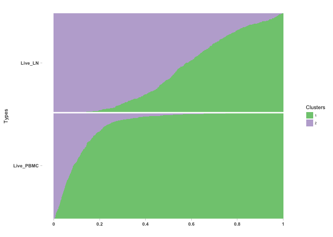

```r
topic_clus_list <- get(load("TFH041/CountClust_Models_filtered_Live.rda"))
PlotCountClust(topic_clus_list[[2]], LiveCells_fac)
```

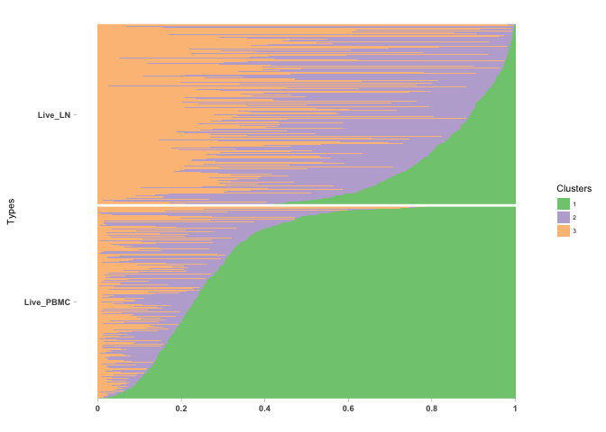

```r
PlotCountClust(topic_clus_list[[3]], LiveCells_fac)
```

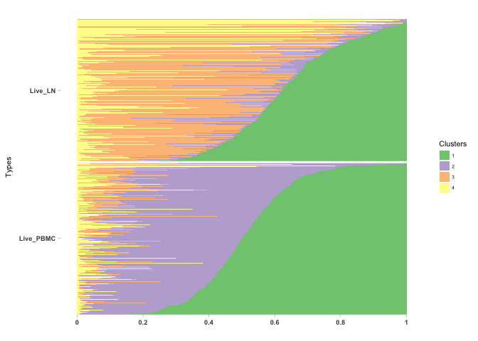

```r
PlotCountClust(topic_clus_list[[4]], LiveCells_fac)
```

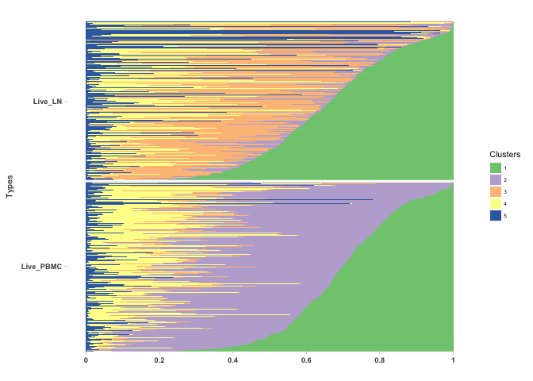

```r
PlotCountClust(topic_clus_list[[5]],  LiveCells_fac)
```

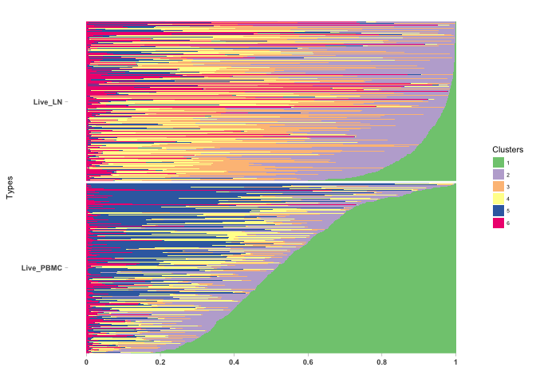

```r
PlotCountClust(topic_clus_list[[6]],  LiveCells_fac)
```

```r
indices <- ExtractTopFeatures(topic_clus_list[[4]]$theta, top_features = 100, method = "poisson", options = "max")
```

```r
imp_genes <- apply(indices, 1, function(x) return(colnames(counts2)[x]))
for(m in 1:dim(imp_genes)[2]){
  write.table(imp_genes[,m], file = paste0("gene_names_", m, ".txt"), quote = FALSE, row.names = FALSE, col.names = FALSE)
}
```

### 2.2.1 top genes - Cluster 1, K = 4

```r
out <- mygene::queryMany(imp_genes[1:50,1],  scopes="symbol", fields=c("name", "summary"), species="human");
```

```
## Finished
## Pass returnall=TRUE to return lists of duplicate or missing query terms.
```

```r
cbind.data.frame(out$name)
```

```
##                                                                                 out$name
## 1                                                              thymosin beta 4, X-linked
## 2                                                                       thymosin beta 10
## 3                                                                                   <NA>
## 4                                     eukaryotic translation elongation factor 1 alpha 1
## 5                                   FAU, ubiquitin like and ribosomal protein S30 fusion
## 6                                                        small nucleolar RNA host gene 5
## 7                                                        small nucleolar RNA host gene 5
## 8                                                        S100 calcium binding protein A4
## 9                                                        cytochrome c oxidase subunit 7C
## 10                                                       cytochrome c oxidase subunit 7C
## 11              ATP synthase, H+ transporting, mitochondrial F1 complex, epsilon subunit
## 12                                     eukaryotic translation elongation factor 1 beta 2
## 13                                                   Rho GDP dissociation inhibitor beta
## 14                                                          basic transcription factor 3
```

[output cut: 42 more lines]

### 2.2.2 top genes - Cluster 2, K = 4

```r
out <- mygene::queryMany(imp_genes[1:50,2],  scopes="symbol", fields=c("name", "summary"), species="human");
```

```
## Finished
## Pass returnall=TRUE to return lists of duplicate or missing query terms.
```

```r
cbind.data.frame(out$name)
```

```
##                                                                           out$name
## 1                                      tumor protein, translationally-controlled 1
## 2                                                  thioredoxin interacting protein
## 3                                                           interleukin 7 receptor
## 4                                                                     calmodulin 1
## 5                                                                       selectin L
## 6                                                                 lymphotoxin beta
## 7                                                  S100 calcium binding protein A6
## 8                                                          integrin subunit beta 1
## 9                                                                             <NA>
## 10                                                                      annexin A1
## 11                                                                            <NA>
## 12                                                                        vimentin
## 13                                 luteinizing hormone/choriogonadotropin receptor
## 14                                                          PCED1B antisense RNA 1
```

[output cut: 36 more lines]

### 2.2.3 top genes - Cluster 3, K = 4

```r
out <- mygene::queryMany(imp_genes[1:50,3],  scopes="symbol", fields=c("name", "summary"), species="human");
```

```
## Finished
## Pass returnall=TRUE to return lists of duplicate or missing query terms.
```

```r
cbind.data.frame(out$name)
```

```
##                                                                       out$name
## 1                       Metastasis associated lung adenocarcinoma transcript 1
## 2  metastasis associated lung adenocarcinoma transcript 1 (non-protein coding)
## 3                                                                    serglycin
## 4                                                                CD3d molecule
## 5                                                 integral membrane protein 2A
## 6                                                MAF bZIP transcription factor
## 7             protein tyrosine phosphatase, receptor type C associated protein
## 8                                                  TBC1 domain family member 4
## 9                               T-cell immunoreceptor with Ig and ITIM domains
## 10                                                                CD2 molecule
## 11                                                     FK506 binding protein 5
## 12                                 cytotoxic T-lymphocyte associated protein 4
## 13                                                    islet cell autoantigen 1
## 14                                                       chemokine like factor
```

[output cut: 37 more lines]

### 2.2.4 top genes - Cluster 4, K = 4

```r
out <- mygene::queryMany(imp_genes[1:50,4],  scopes="symbol", fields=c("name", "summary"), species="human");
```

```
## Finished
## Pass returnall=TRUE to return lists of duplicate or missing query terms.
```

```r
#cbind.data.frame(out$name)
cbind.data.frame(out$name)
```

```
##                                                                                   out$name
## 1                                                                               actin beta
## 2                                                                     myosin light chain 6
## 3                                                                               profilin 1
## 4                                                 glyceraldehyde-3-phosphate dehydrogenase
## 5                                                                            actin gamma 1
## 6                                                     histone cluster 1 H4 family member c
## 7                                                                high mobility group box 2
## 8                                                                         tubulin alpha 1b
## 9                                                              H2A histone family member Z
## 10                                                coactosin like F-actin binding protein 1
## 11                                                                 Y-box binding protein 1
## 12                                                              peptidylprolyl isomerase A
## 13                                                          lymphocyte cytosolic protein 1
## 14                                                                              stathmin 1
```

[output cut: 36 more lines]

## 2.3 Expression profile validation

We validate the expression profile of some of the genes that were picked up by the clustering method. We first perform a hard assignment of each single cell to the cluster with the highest grade of membership. We also pool in the metadata on whether that cell is from the Lymph node or it is PBMC.

```r
topic_clus_list <- get(load("TFH041/CountClust_Models_filtered_Live.rda"))
indices <- ExtractTopFeatures(topic_clus_list[[4]]$theta, top_features = 100, method = "poisson", options = "max")
fac1 <- apply(topic_clus_list[[4]]$omega, 1, function(x) return(which.max(x)))
conditions <- paste0(LiveCells_fac, "|", paste0("Clus-", fac1))
```

### 2.3.1 First cluster genes, K = 4

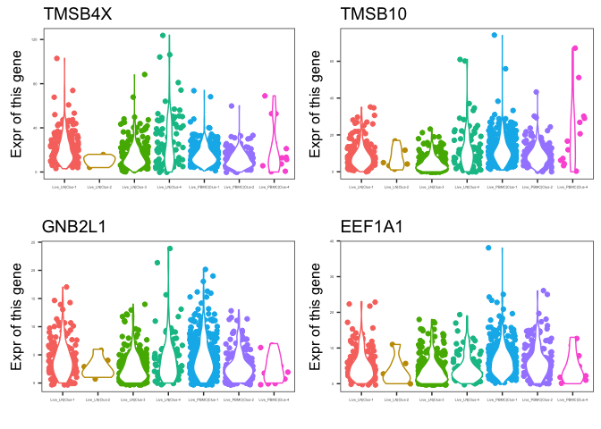

```r
data_ggplot <- as.data.frame(counts2[, indices[1,c(1, 2, 3, 4)]])
colnames(data_ggplot) <- c("Expr1", "Expr2", "Expr3", "Expr4")
data_ggplot$Condition <- conditions
plot1 <- ggplot(data = data_ggplot) + geom_jitter(aes(x = Condition, y = Expr1, color = Condition)) + geom_violin(aes(x = Condition, y = Expr1, color = Condition)) + labs(x = '', y = 'Expr of this gene') + guides(color = 'none') + theme(axis.text.x = element_text(size=3)) + theme(axis.text.y = element_text(size=3)) + ggtitle(paste0(imp_genes[1,1]))
plot2 <- ggplot(data = data_ggplot) + geom_jitter(aes(x = Condition, y = Expr2, color = Condition)) + geom_violin(aes(x = Condition, y = Expr2, color = Condition)) + labs(x = '', y = 'Expr of this gene') + guides(color = 'none') + theme(axis.text.x = element_text(size=3)) + theme(axis.text.y = element_text(size=3)) + ggtitle(paste0(imp_genes[2,1]))
plot3 <- ggplot(data = data_ggplot) + geom_jitter(aes(x = Condition, y = Expr3, color = Condition)) + geom_violin(aes(x = Condition, y = Expr3, color = Condition)) + labs(x = '', y = 'Expr of this gene') + guides(color = 'none') + theme(axis.text.x = element_text(size=3)) + theme(axis.text.y = element_text(size=3)) + ggtitle(paste0(imp_genes[3,1]))
plot4 <- ggplot(data = data_ggplot) + geom_jitter(aes(x = Condition, y = Expr4, color = Condition)) + geom_violin(aes(x = Condition, y = Expr4, color = Condition)) + labs(x = '', y = 'Expr of this gene') + guides(color = 'none') + theme(axis.text.x = element_text(size=3)) + theme(axis.text.y = element_text(size=3)) + ggtitle(paste0(imp_genes[4,1]))
plot_grid(plot1, plot2, plot3, plot4, ncol = 2, align = 'h')
```

### 2.3.2 Second cluster genes, K = 4

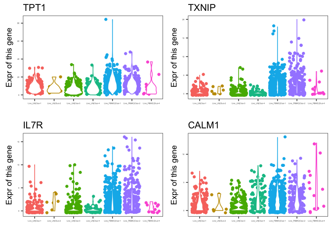

```r
data_ggplot <- as.data.frame(counts2[, indices[2,c(1, 2, 3, 4)]])
colnames(data_ggplot) <- c("Expr1", "Expr2", "Expr3", "Expr4")
data_ggplot$Condition <- conditions
plot1 <- ggplot(data = data_ggplot) + geom_jitter(aes(x = Condition, y = Expr1, color = Condition)) + geom_violin(aes(x = Condition, y = Expr1, color = Condition)) + labs(x = '', y = 'Expr of this gene') + guides(color = 'none') + theme(axis.text.x = element_text(size=3)) + theme(axis.text.y = element_text(size=3)) + ggtitle(paste0(imp_genes[1,2]))
plot2 <- ggplot(data = data_ggplot) + geom_jitter(aes(x = Condition, y = Expr2, color = Condition)) + geom_violin(aes(x = Condition, y = Expr2, color = Condition)) + labs(x = '', y = 'Expr of this gene') + guides(color = 'none') + theme(axis.text.x = element_text(size=3)) + theme(axis.text.y = element_text(size=3)) + ggtitle(paste0(imp_genes[2,2]))
plot3 <- ggplot(data = data_ggplot) + geom_jitter(aes(x = Condition, y = Expr3, color = Condition)) + geom_violin(aes(x = Condition, y = Expr3, color = Condition)) + labs(x = '', y = 'Expr of this gene') + guides(color = 'none') + theme(axis.text.x = element_text(size=3)) + theme(axis.text.y = element_text(size=3)) + ggtitle(paste0(imp_genes[3,2]))
plot4 <- ggplot(data = data_ggplot) + geom_jitter(aes(x = Condition, y = Expr4, color = Condition)) + geom_violin(aes(x = Condition, y = Expr4, color = Condition)) + labs(x = '', y = 'Expr of this gene') + guides(color = 'none') + theme(axis.text.x = element_text(size=3)) + theme(axis.text.y = element_text(size=3)) + ggtitle(paste0(imp_genes[4,2]))
plot_grid(plot1, plot2, plot3, plot4, ncol = 2, align = 'h')
```

### 2.3.3 Third cluster genes, K = 4

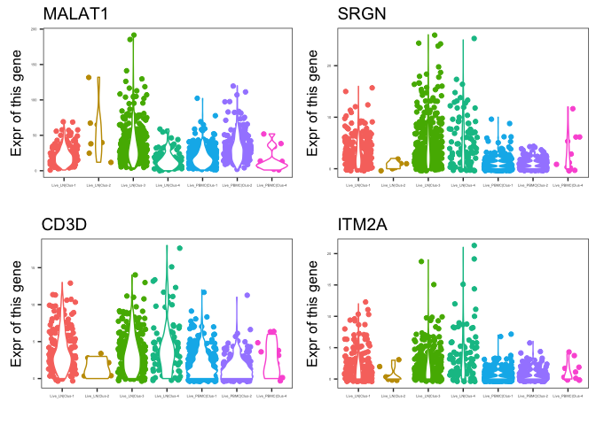

```r
data_ggplot <- as.data.frame(counts2[, indices[3,c(1, 2, 3, 4)]])
colnames(data_ggplot) <- c("Expr1", "Expr2", "Expr3", "Expr4")
data_ggplot$Condition <- conditions
plot1 <- ggplot(data = data_ggplot) + geom_jitter(aes(x = Condition, y = Expr1, color = Condition)) + geom_violin(aes(x = Condition, y = Expr1, color = Condition)) + labs(x = '', y = 'Expr of this gene') + guides(color = 'none') + theme(axis.text.x = element_text(size=3)) + theme(axis.text.y = element_text(size=3)) + ggtitle(paste0(imp_genes[1,3]))
plot2 <- ggplot(data = data_ggplot) + geom_jitter(aes(x = Condition, y = Expr2, color = Condition)) + geom_violin(aes(x = Condition, y = Expr2, color = Condition)) + labs(x = '', y = 'Expr of this gene') + guides(color = 'none') + theme(axis.text.x = element_text(size=3)) + theme(axis.text.y = element_text(size=3)) + ggtitle(paste0(imp_genes[2,3]))
plot3 <- ggplot(data = data_ggplot) + geom_jitter(aes(x = Condition, y = Expr3, color = Condition)) + geom_violin(aes(x = Condition, y = Expr3, color = Condition)) + labs(x = '', y = 'Expr of this gene') + guides(color = 'none') + theme(axis.text.x = element_text(size=3)) + theme(axis.text.y = element_text(size=3)) + ggtitle(paste0(imp_genes[3,3]))
plot4 <- ggplot(data = data_ggplot) + geom_jitter(aes(x = Condition, y = Expr4, color = Condition)) + geom_violin(aes(x = Condition, y = Expr4, color = Condition)) + labs(x = '', y = 'Expr of this gene') + guides(color = 'none') + theme(axis.text.x = element_text(size=3)) + theme(axis.text.y = element_text(size=3)) + ggtitle(paste0(imp_genes[4,3]))
plot_grid(plot1, plot2, plot3, plot4, ncol = 2, align = 'h')
```

### 2.3.4 Fourth cluster genes, K = 4

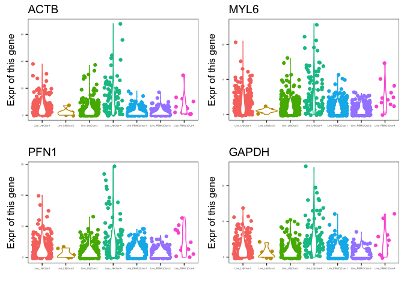

```r
data_ggplot <- as.data.frame(counts2[, indices[4,c(1, 2, 3, 4)]])
colnames(data_ggplot) <- c("Expr1", "Expr2", "Expr3", "Expr4")
data_ggplot$Condition <- conditions
plot1 <- ggplot(data = data_ggplot) + geom_jitter(aes(x = Condition, y = Expr1, color = Condition)) + geom_violin(aes(x = Condition, y = Expr1, color = Condition)) + labs(x = '', y = 'Expr of this gene') + guides(color = 'none') + theme(axis.text.x = element_text(size=3)) + theme(axis.text.y = element_text(size=3)) + ggtitle(paste0(imp_genes[1,4]))
plot2 <- ggplot(data = data_ggplot) + geom_jitter(aes(x = Condition, y = Expr2, color = Condition)) + geom_violin(aes(x = Condition, y = Expr2, color = Condition)) + labs(x = '', y = 'Expr of this gene') + guides(color = 'none') + theme(axis.text.x = element_text(size=3)) + theme(axis.text.y = element_text(size=3)) + ggtitle(paste0(imp_genes[2,4]))
plot3 <- ggplot(data = data_ggplot) + geom_jitter(aes(x = Condition, y = Expr3, color = Condition)) + geom_violin(aes(x = Condition, y = Expr3, color = Condition)) + labs(x = '', y = 'Expr of this gene') + guides(color = 'none') + theme(axis.text.x = element_text(size=3)) + theme(axis.text.y = element_text(size=3)) + ggtitle(paste0(imp_genes[3,4]))
plot4 <- ggplot(data = data_ggplot) + geom_jitter(aes(x = Condition, y = Expr4, color = Condition)) + geom_violin(aes(x = Condition, y = Expr4, color = Condition)) + labs(x = '', y = 'Expr of this gene') + guides(color = 'none') + theme(axis.text.x = element_text(size=3)) + theme(axis.text.y = element_text(size=3)) + ggtitle(paste0(imp_genes[4,4]))
plot_grid(plot1, plot2, plot3, plot4, ncol = 2, align = 'h')
```